# EL VUELO DE SIPRI

Docentes Interinos en Andalucía

JRLAB. Jose Ramon Hernandez Galan

11/5/2020

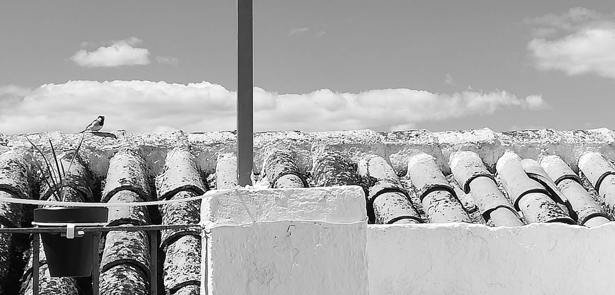

## Introducción

Si eres personal docente interino en Andalucía o aspiras a serlo no hace falta que te presente a Sipri. Si no es así, lo conocerás a lo largo de este artículo.

## SIPRI

SIPRI es el **SI**stema de **PR**ovisionamiento de **I**nterinos docentes de la Junta de Andalucía. La primera vez que oí hablar de él no sé porqué me sonó a pájaro, igual en ese momento me vi influenciado por el logo del pájaro de Twiter que acompaña a las páginas de la Junta. De ahí el nombre del artículo.

En ocasiones, la vida del interino es similar a la de un pájaro, volando de un sitio a otro cubriendo las bajas del personal docente a lo largo y ancho de Andalucía. Es por esto que el título es una buena metáfora de la vida interina.

## ¿Cúanto vuela SIPRI?

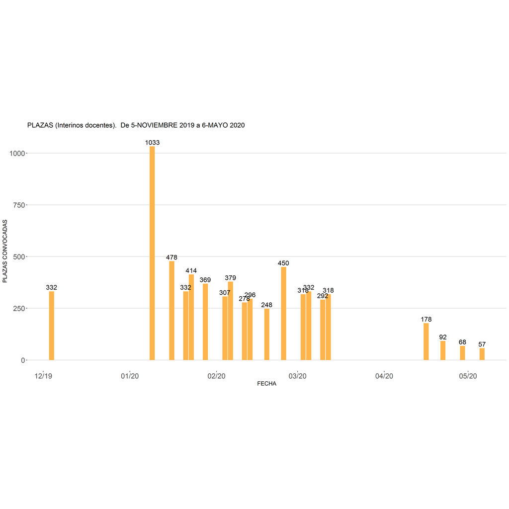

## ¿Cómo vuela SIPRI?

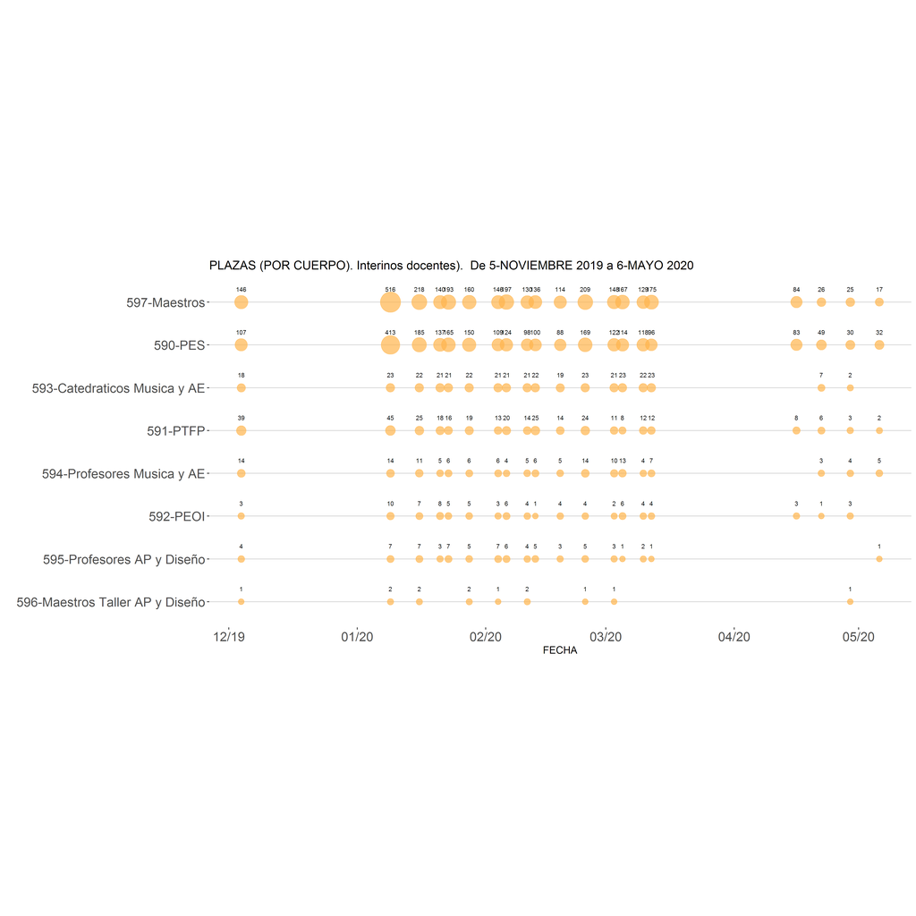

## Volando con Sipri

Si quieres personalizar la vista del vuelo de Sipri puedes utilizar nuestra aplicación web interactiva.

[**Web App interactiva**](https://jrlab.shinyapps.io/sipri)

Si necesitas una vista más profunda del vuelo de Sipri o tienes cualquier consulta puedes ponerte en contacto. En la sección de contacto podrás encontrar nuestra dirección.

## Referencias

Datos: recogidos de la Junta de Andalucía.

## Contacto

JRLAB.2020. Puedes escribirme para cualquier aclaración a jrlabnotifier@gmail.com

[**JRLAB web**](https://www.jrlab.es)

## Licencia

Este obra está bajo una [licencia de Creative Commons Reconocimiento-NoComercial-CompartirIgual 4.0 Internacional](http://creativecommons.org/licenses/by-nc-sa/4.0/).